# One Person Lab 白皮书

> 让一个人也能拥有专业团队级的复杂知识工作推进能力

发布日期：2026-07-13

最近修订：2026-08-16

适用对象：希望理解 One Person Lab 为什么这样设计，以及这种设计怎样让复杂知识工作更好用、更可信的用户、合作者、早期采用者和技术决策者。

核心判断：One Person Lab 让 AI 从一次回答走向可复查、可交付、可持续推进的专业工作。

## 从生成走向完成

AI 已经很擅长回答一个问题、生成一段代码或润色一份材料。但论文、基金申请、正式汇报、书稿这类工作，很少在一次对话里结束。它们跨越数天、数周甚至更久，中间要持续补材料、比较路线、修改文件、接受审阅、修正错误并做出关键决定。

真正困难的是让每一次生成都进入一条持续完成、可以复查的工作线：

- 多轮工作之后，当前究竟推进到了哪里？
- 哪些材料和证据支撑了现有判断，最新版成果在哪里？
- 谁在执行，谁在独立审阅，什么结论仍需负责人确认？
- 出现质量问题时，怎样继续形成有用成果，同时如实标记完成边界？
- 用户离开后，工作怎样保留线索；回来时，又怎样立即知道卡点和下一步？

对话工具擅长处理当下问题，项目管理工具擅长登记任务，固定自动化擅长执行确定步骤。复杂知识工作还需要一套新的工作方式：让 AI 有足够空间做专家判断，同时让阶段、文件、证据、责任和交付边界始终清楚。

这就是 One Person Lab（OPL）要解决的问题。

## OPL 的答案：把 AI 组织成一支可接力的专业团队

OPL 从最终成果反推工作结构，把复杂任务组织成一系列能产生真实增量、又能根据证据灵活调整的阶段：准备材料、形成方案、执行创作、独立审阅、修订完善、交付收口。

每个阶段都围绕可检查的成果工作。AI 执行者可以阅读材料、比较方案、调用工具、创作内容并根据反馈继续修订；独立审阅者从不同角色检查证据、逻辑、质量和交付风险；系统则保存阶段状态、文件、证据引用、责任方、卡点和恢复线索。

用户直接感知到：

- 工作持续向下一版成果推进，每轮对话都沉淀为可继续的增量；
- 每一版都能打开、检查、修改和继续交接；
- 质量差距被明确指出，状态始终与实际进展一致；
- 需要人做决定时，界面直接说明“谁需要做什么”。

OPL 用清楚的边界释放 AI。开放式判断交给 AI，权限、证据、责任和恢复交给系统。

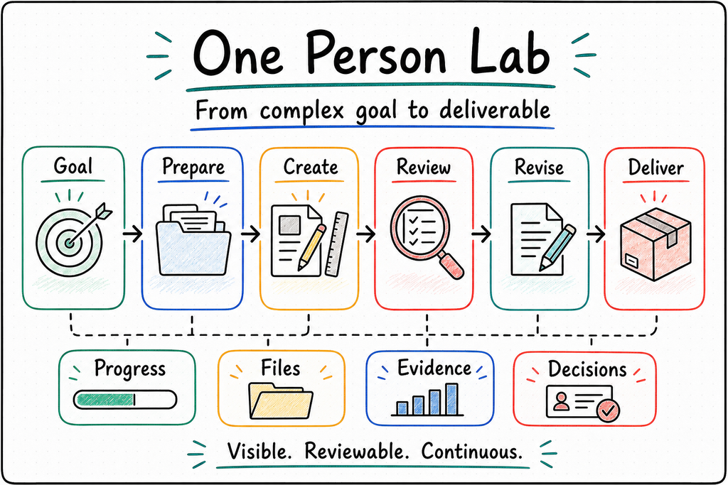

One Person Lab 把复杂目标组织为可见、可复查、可持续推进的成果链。

## 认知计算：在阶段内完成真正的专家工作

固定自动化适合“先做 A，再做 B，最后输出 C”。复杂知识工作却经常需要反复理解、比较、推翻、重写和审阅。论文的论证路线会因为新证据改变，基金申请的创新点会在模拟评审后重构，正式汇报的故事线也会在视觉呈现中被重新组织。

OPL 把这种阶段内的开放式专家工作称为**认知计算**：AI 在一个目标清楚、边界可见、结果可接力的阶段里完成理解、比较、创作、审阅和修订。

这种设计有两个重要结果。

第一，AI 执行者越强，阶段内的真实工作能力就越强。模型、提示词、专业技能和领域知识的进步，可以直接提升理解、判断和创作质量，让专家思路在开放的阶段中充分发挥。

第二，能力提升与可控运行同步发生。OPL 让每次阶段推进都有材料范围、权限边界、预期成果、证据引用、独立审阅和交接要求。AI 可以自由决定如何完成工作，最终结论始终由明确的责任方给出。

因此，OPL 的基本协作单元是一次有目标、有产物、有审阅、有去向的专业工作尝试。

## 四层生态：一个体验，清楚分工

One Person Lab 对用户呈现为一个连续产品，并用四个稳定对象降低安装、使用和维护成本。

**OPL Base** 是由 OPL Framework 提供的运行底座。它负责启动、阶段推进、长期运行、恢复、工作空间、证据与交接，让复杂任务可以被启动、暂停、继续和收口。具体执行工具与能力实现可以变化，工作本身的阶段、成果与责任关系保持稳定。

**OPL App** 是本地工作面和产品体验负责人，让用户选择任务、查看进度、打开文件、处理卡点和接收更新。界面可以持续演进，但产品定义和工作语言只有一份；正式发布始终提供统一的任务、能力、状态和操作体验。

**OPL Packages** 是可安装能力层。智能体、技能、工具和工作流都通过能力包进入生态；每个能力包可以按真实节奏独立安装、版本化和发布，Base 负责发现和运行，App 负责呈现，能力提供者继续负责自己的专业边界。

**OPL Cloud** 是 One Person Lab 正在建设和持续交付的云端产品，把同一条工作线延伸到在线工作空间、账号治理、托管资源、组织协作和智能体服务。它与 Base、App、Packages 共同构成完整而连续的四层产品体系。

Foundry Agents 是 OPL Packages 中的专业智能体家族。不同领域需要不同的材料理解、工作方法、质量标准和交付责任。OPL 当前的五个标准专业智能体是：

- [Med Auto Science（MAS）](https://github.com/gaofeng21cn/med-autoscience)：医学研究与论文交付；
- [Med Auto Grant（MAG）](https://github.com/gaofeng21cn/med-autogrant)：基金方向、申请书、模拟评审与修订；
- [RedCube AI（RCA）](https://github.com/gaofeng21cn/redcube-ai)：负责演示文稿、报告、叙事、渲染、审阅与导出；
- [OPL Meta Agent（OMA）](https://github.com/gaofeng21cn/opl-meta-agent)：理解新建、接管和改进目标，形成智能体蓝图、评测规格和基于证据的演进建议；
- [OPL Book Forge（OBF）](https://github.com/gaofeng21cn/opl-bookforge)：面向书籍与长篇手稿的策划、写作、审阅与交付。

五者统一使用 OPL 的标准运行与工作面，但专业判断与最终责任仍然归属清楚。OMA 负责理解新 Agent 应解决的问题、形成设计并提出演进建议；独立评估负责检验这些建议，目标领域的负责人决定是否采用。

四层之间有一条简单原则：Base 负责“工作怎样可靠推进”，Packages 提供“系统能完成什么专业工作”，App 负责“用户怎样看见并操作”，Cloud 负责在线治理、托管资源与协作服务；专业智能体及其负责人继续决定“这个领域什么算好、什么可以交付”。

## 能力持续升级，产品体验保持一致

OPL 根据一项工作的真实需要动态装配运行、工作空间、能力发现、证据、连接和呈现能力。每项能力都有清楚责任，可以独立验证和演进；用户不需要理解这些能力在内部如何组织，只需围绕目标、成果和下一步工作。

这种设计带来三个直接收益：升级执行、连接、观测或界面能力时，不必打断整条工作线；重要能力可以独立测试、比较和回退；正式产品只提供少量经过完整验证的工作组合，不把内部选择变成用户的配置负担。

能力实现可以变化，任务、文件、证据、权限和专业判断的来源保持稳定。局部升级因此不会让用户重新建立项目，也不会让界面显示取代真正的运行事实或专业结论。

## 三类用户可感知的机制

OPL 把运行、工作空间、能力发现、证据、控制和连接组织成三类用户可以直接感知的机制。

| 用户感知的机制 | 背后的设计 | 带来的实际体验 |
| --- | --- | --- |
| **工作始终围绕下一份成果推进** | 阶段式认知计算；执行者与独立审阅者分离；可消费成果允许带着明确质量债进入下一轮 | 用户持续拿到可打开、可比较、可修改的版本，并能看见任务的实际进展 |
| **专业能力即装即用，判断权归属清楚** | 专业 Agent 描述自己的阶段、能力和质量边界，OPL 提供统一工作面，领域负责人保留专业裁决 | MAS、MAG、RCA 等使用同一套入口、进度和文件体验，同时仍由真正懂该领域的人与 Agent 给出质量与交付判断 |
| **工作可以停下、解释、恢复和交接** | 工作空间保存材料与产物，运行层保存尝试与恢复线索，证据层只引用真实来源，工作台优先显示当前责任方和下一步 | 用户离开后仍保有完整上下文；失败时能知道原因；换人或换阶段时能从已有成果继续 |

这三类机制共同解决一个常见矛盾：专业工作需要开放判断，而长期交付需要稳定秩序。OPL 让开放判断与稳定秩序同时成立。

## 标准专业智能体：声明能力，保留权威

传统做法往往让每个专业智能体各自开发一套运行器、队列、状态页、文件系统和安装方式。短期看起来灵活，长期却会让用户面对多个入口、多个更新器和多套互相冲突的状态。

OPL 的目标形态更简单：一个标准专业智能体由三部分组成。

1. **专业工作模型**：说明这个领域有哪些阶段、需要什么能力、会形成哪些成果，以及质量边界在哪里。
2. **统一工作面**：由 OPL 提供入口、运行、进度、文件、恢复和日常维护体验。
3. **专业判断**：由领域 Agent 与真正的负责人给出质量结论、交付决定和需要人工处理的问题。

共同的运行外围由 OPL 上收，每个 Agent 因此可以把更多精力放在自己的专业差异上。医学研究按证据与发表标准判断，基金按创新性与可资助性审阅，视觉交付按叙事、可读性与导出结果验收。

对用户而言，这意味着学习一次，就可以使用多个专业 Agent；对产品而言，这意味着各领域可以直接共享运行、恢复、文件和界面升级；对专业责任而言，“质量合格”始终由对应领域的 Agent 与负责人宣布。

## 一个成果如何从想法走到可交付

下面用一个医学研究项目说明这套设计。这个故事表达 OPL 的工作方式，每项研究可以根据自身需要调整具体步骤。

一位研究者把数据说明、研究问题、已有图表和参考文献放进工作空间，希望形成一篇可以继续投稿准备的论文初稿。

**第一步，形成可工作的研究上下文。** MAS 读取材料，识别研究问题、数据限制和需要补齐的证据。OPL 保存材料位置、当前目标和阶段边界。研究者直接看到一份可确认的材料摘要、缺口和下一步，内部扫描日志留在诊断层。

**第二步，执行者形成成果增量。** AI 执行者围绕研究问题组织分析结果、图表解释和稿件结构，产出新的稿件与证据引用。它可以自主比较路线、调整论证和调用工具；OPL 为思考路径与工具选择保留充分的自主空间。

**第三步，独立审阅者提出异议。** reviewer 从独立视角检查数字、证据、论证和发表风险。它发现一项次要结论的证据仍不充分，但主结果、方法和稿件骨架已经可以支持下一轮工作。

**第四步，有成果就继续，就绪边界保持清楚。** 可消费成果已经形成，后续修订可以继续；同时，证据不足被清楚保留为质量债。成果可供下一轮使用，并不表示它已经通过专业质量判断或获得研究负责人确认。

**第五步，修订并交回真正的责任方。** 下一轮针对质量债补证据、收紧 claim、更新稿件。MAS 的领域质量门和研究负责人决定是否接受当前版本、继续修订或进入投稿准备。OPL 负责把文件、证据、审阅意见和责任流转完整交到他们手里。

用户最终获得一条可以复查的成果链：材料有来源，版本有位置，审阅有独立角色，问题有去向，最终结论有真正的责任方。

## 五条设计原则

OPL 的好用来自一组稳定设计判断。它们约束系统如何取舍，也解释为什么界面、运行和专业 Agent 会呈现为现在的样子。

### AI-first, contract-light

**AI 做专家工作，合同守住下限。**

理解、判断、创作、审阅和修订优先交给 AI。合同聚焦身份、权限、安全动作、证据、卡点、恢复和交接，为工具顺序与创作策略保留开放空间。这样，更强的模型、更好的技能和更成熟的领域知识可以直接转化为更好的成果。

### 交付即推进

**有可接力成果，就推动工作向前。**

真实进度以成果、证据、决定和交接为依据。若阶段已经形成可消费成果，剩余质量差距可以在清楚边界内继续修订，OPL 会保留问题和责任方。带质量债推进表示已有可继续使用的成果，不表示领域质量或正式交付已经通过。

### 目标先于路径

**先问要交付什么，再决定系统怎样工作。**

论文、基金、视觉交付和书稿需要不同专业路线。目录、状态、运行器和工具都服务于用户目标。与成果、证据、责任或交接无关的复杂面，应当收薄、下沉或退役。

### 真相归主

**谁拥有事实，谁给结论。**

Framework 说明运行是否发生、文件和证据在哪里；App 说明用户当前能看见和操作什么；Foundry Agent 和独立审阅者负责领域质量判断；真正的负责人作出需要授权的最终决定。

### 抓大放小

**把硬门留给关键边界。**

启动安全、权限、不可逆动作和必要人工确认必须严格保护；普通提示、诊断、评分和改进建议保持轻量并服务当前工作。系统守住大边界，AI 才能在阶段内充分工作。

## 简单维护：四个产品对象，一套连续体验

强大的系统把内部复杂性留在内部。用户只需认识 OPL 的四个稳定产品对象：

- **OPL Base**：Framework、执行环境和通用运行能力；
- **OPL App**：桌面工作台与统一的产品体验；
- **OPL Packages**：MAS、MAG、RCA、OMA、OPL Book Forge、工作流与能力包；
- **OPL Cloud**：在线工作空间、账号治理、托管资源、协作与智能体服务。

Base 管共同底座，App 管本地体验，Packages 管专业能力，Cloud 管在线服务。前三类以本地软件方式安装和更新，Cloud 通过在线产品持续交付；四者采用各自合适的交付方式，共同维持一致的任务、成果、证据和责任语言。各项能力可以独立演进和组合，用户仍只需选择适合自己的工作方式。

OPL Cloud 扩展工作位置、资源与治理能力，让用户从本机进入在线工作空间、远端资源或团队协作时，继续沿用同一套专业工作模型。

One Person Lab App 始终作为一个产品定义行为和正式发布体验。界面可以持续演进，用户的任务、能力包、状态、操作和专业判断始终保持连续；每次正式发布只呈现一套经过完整验证的产品体验。

## 信任如何由证据建立

信任来自系统持续回答几个关键问题：要交付什么，推进到哪里，当前成果在哪里，依据是什么，谁负责下一步，什么判断仍在等待授权。

OPL 用克制建立这种信任：

- **运行与质量分别证明。** 阶段结束或文件生成说明工作进展，领域质量结论由专业责任方给出。
- **执行与终审角色分离。** 复杂质量判断进入独立审阅与领域负责人路径。
- **成果及时呈现。** 可消费成果继续推进，质量债同步记录并进入修复路径。
- **界面优先呈现行动信息。** 默认界面先显示成果、责任方、卡点和下一步，技术细节在需要时展开。
- **专业判断归领域 Agent。** OPL 负责承载、连接和呈现，领域 Agent 负责真正的专业判断。

这套边界让 OPL 既有能力长期运行，也能如实说明距离就绪还缺什么。用户得到一支会持续交付、接受审阅、暴露问题并把决定交回正确责任方的 AI 专业团队。

## 结语

One Person Lab 的长期目标，是让一个人也能拥有过去只有专业团队才能提供的持续推进能力。

AI 负责理解、比较、创作、审阅和修订；OPL Framework 负责阶段、工作空间、证据、恢复与交接；App 把这些能力变成清楚、可操作的工作体验，Cloud 将体验扩展到在线工作空间、远端资源和协作；MAS、MAG、RCA、OMA 与 OPL Book Forge 五个标准 Foundry Agents 负责各自的专业判断，并把最终交付或采用决定交回相应负责人。

OPL 相信，真正优秀的 AI 产品既能在用户提出问题时给出高质量回应，也能在漫长、复杂、充满反复的正式工作中，始终让下一份成果更近，让每个判断有依据，让每个问题有去向，让最终交付值得相信。

了解更多：

- [One Person Lab](https://github.com/gaofeng21cn/one-person-lab)
- [One Person Lab App](https://github.com/gaofeng21cn/one-person-lab-app)
- [OPL Cloud](https://github.com/gaofeng21cn/one-person-lab-cloud)
- [OPL Framework 白皮书](https://gaofeng21cn.github.io/one-person-lab/latest/whitepapers/opl-framework-whitepaper.html)